# Moccasin Terrace Modflow6

2026-09-07

# 1 Project overview

This project is intended to setup a basic modflow6 model on the Moccasin terrace as a proof of concept. The model currently is not intended to serve as a calibrated and accurate groundwater model suitable for solute fate and transport questions. Notably considering the very flat nature of the terrace a shale boundary bottom layer or interpolated shale boundary is needed to produce a realistic head contour plot.The basic model skeleton runs without incorporating recharge or discharge into the model which currently results in model failure. This model is still under development.

The main motivation of this proof of concept model is to try and examine simulated groundwater flows around the M1 monitoring well on the Moccasin terrace to try and understand what the contributing area to this might be.

# 2 Libaries and path setup

```python
from pathlib import Path
import numpy as np
import geopandas as gpd
import matplotlib.pyplot as plt
import flopy
from flopy.utils import Raster
from flopy.utils.gridintersect import GridIntersect
import rasterio
import rasterstats  # needed by flopy Raster resampling
import pandas as pd
from shapely.geometry import Point
from scipy.interpolate import griddata
import rasterio
from rasterio.transform import from_origin

# 1. Directory and input setup
project_dir = Path(r"D:/MODFLOW6/Moccasin_terrace_project")
input_dir = project_dir / "01_input"
model_ws = project_dir / "03_increment" / "20260907"
model_ws.mkdir(parents=True, exist_ok=True)

dem_path = input_dir / "Moccasin_DEM_30m.tif"
bnd_path = input_dir / "Moccasin_Terrace_filled_boundary.shp"
nhd_path = input_dir / "USGS_NHD"/ "Judith River" / "Shape" / "NHDFlowline.shp"
M1_well_path = input_dir / "M1 Well Location.xlsx"
red_shed_lake_path = input_dir / "Red_Shed_Lake.shp"
```

# 3 DEM and shapefile import

```python
## Read boundary and Red Shed Lake
boundary = gpd.read_file(bnd_path)
red_shed_lake = gpd.read_file(red_shed_lake_path)

with rasterio.open(dem_path) as src:
    Moccasin_dem = src.read(1)
    dem_crs = src.crs
    transform = src.transform

print("Boundary CRS:", boundary.crs)
```

```python
print("Red Shed Lake CRS:", red_shed_lake.crs)
```

```python
print("DEM CRS:", dem_crs)
```

```python
## Reproject Red Shed Lake if necessary
if red_shed_lake.crs != dem_crs:
    red_shed_lake = red_shed_lake.to_crs(dem_crs)

print("Red Shed Lake CRS after reprojection:", red_shed_lake.crs)
```

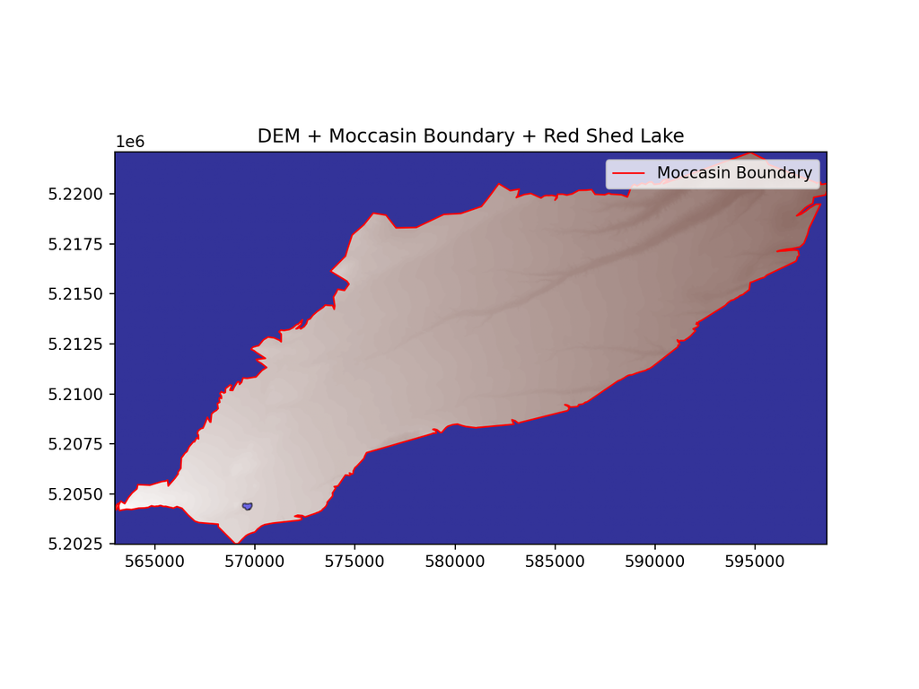

```python
# raster bounds for plotting
height, width = Moccasin_dem.shape
left, top_raster = transform * (0, 0)
right, bottom = transform * (width, height)


## DEM + boundary + Red Shed Lake check

fig, ax = plt.subplots(figsize=(8, 6))

ax.imshow(
    Moccasin_dem,
    cmap="terrain",
    extent=[left, right, bottom, top_raster]
)

boundary.boundary.plot(
    ax=ax,
    color="red",
    linewidth=1,
    label="Moccasin Boundary"
)

red_shed_lake.plot(
    ax=ax,
    color="blue",
    edgecolor="black",
    alpha=0.5,
    label="Red Shed Lake"
)

ax.set_title("DEM + Moccasin Boundary + Red Shed Lake")
ax.set_aspect("equal")
ax.legend()

plt.show()
```

# 4 Grid construction

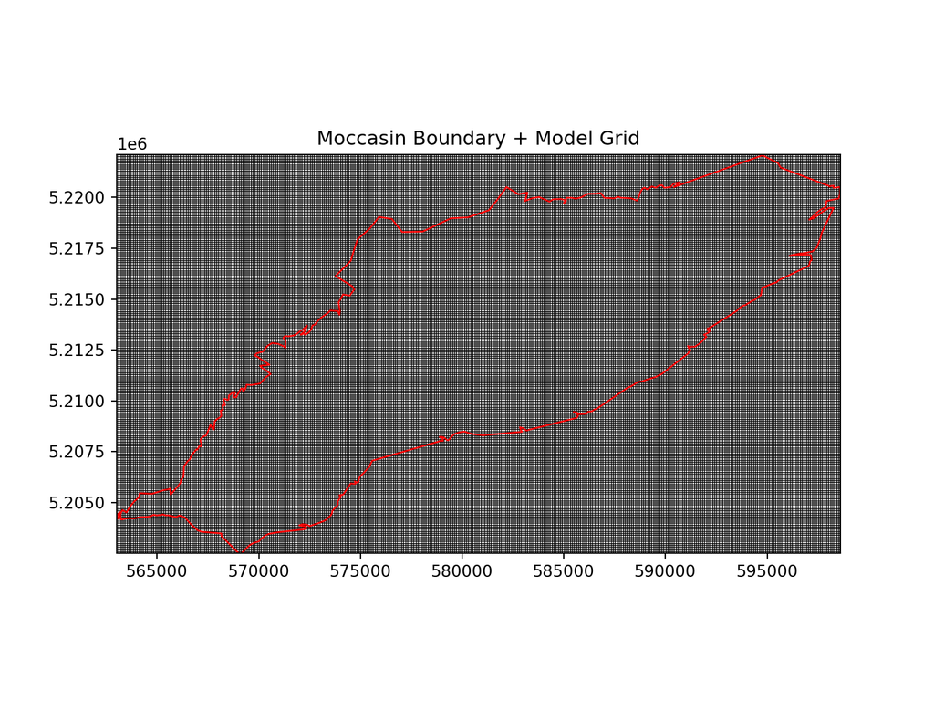

```python
## Construct model grid
cellsize = 100.0  # meters

xmin, ymin, xmax, ymax = boundary.total_bounds
Lx = xmax - xmin
Ly = ymax - ymin

ncol = int(np.ceil(Lx / cellsize))
nrow = int(np.ceil(Ly / cellsize))

delr = np.full(ncol, cellsize)
delc = np.full(nrow, cellsize)

# Structured Grid for QC, intersection, and raster resampling
modelgrid = flopy.discretization.StructuredGrid(
    delr=delr,
    delc=delc,
    top=np.zeros((nrow, ncol)),
    botm=np.full((1, nrow, ncol), -10.0),
    xoff=xmin,
    yoff=ymin,
    crs=dem_crs,
)

## Boundary and grid check
fig, ax = plt.subplots(figsize=(8, 6))
pmv = flopy.plot.PlotMapView(modelgrid=modelgrid, ax=ax)
pmv.plot_grid(colors="black", linewidth=0.5)
boundary.boundary.plot(ax=ax, color="red", linewidth=1)
ax.set_title("Moccasin Boundary + Model Grid")
ax.set_aspect("equal")
plt.show()
```

```python
print(f"Total cells: {nrow * ncol}")
```

# 5 Cell activation

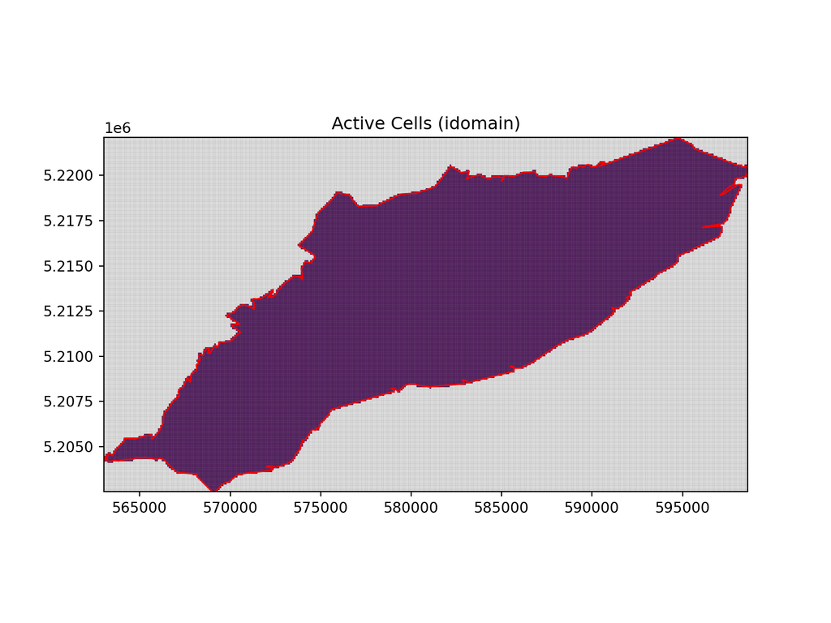

```python
## Create idomain from boundary
model_poly = boundary.union_all()

idomain = np.zeros((1, nrow, ncol), dtype=int)

ix = GridIntersect(modelgrid)
result = ix.intersect(model_poly)

for cellid in result.cellids:
    r, c = cellid
    idomain[0, r, c] = 1

## active cell check
fig, ax = plt.subplots(figsize=(8, 6))
pmv = flopy.plot.PlotMapView(modelgrid=modelgrid, ax=ax)
pmv.plot_array(idomain[0], masked_values=[0])
pmv.plot_grid(alpha=0.15)
boundary.boundary.plot(ax=ax, color="red", linewidth=1)
ax.set_title("Active Cells (idomain)")
ax.set_aspect("equal")
plt.show()
```

```python
# Identify Red Shed Lake cells for CHD

ix = GridIntersect(modelgrid)

lake_result = ix.intersect(
    red_shed_lake.union_all()
)

lake_cells = []

for cellid in lake_result.cellids:
    r, c = cellid

    if idomain[0, r, c] == 1:
        lake_cells.append((0, r, c))

print("Red Shed Lake cells:", len(lake_cells))
```

# 6 DEM resampling

```python
## Resample DEM to model grid
raster = Raster.load(str(dem_path))

top = raster.resample_to_grid(
    modelgrid,
    band=raster.bands[0],
    method="nearest",
    extrapolate_edges=True,
)

top = np.asarray(top, dtype=float)

active_nan = (idomain[0] == 1) & np.isnan(top)
print("Active cells with NaN top:", active_nan.sum())
```

```python
# DEM in active domain only
top_active = np.where(idomain[0] == 1, top, np.nan)

fig, ax = plt.subplots(figsize=(8, 6))
pmv = flopy.plot.PlotMapView(modelgrid=modelgrid, ax=ax)
quad = pmv.plot_array(top_active)
pmv.plot_grid(alpha=0.15)
boundary.boundary.plot(ax=ax, color="red", linewidth=1)
plt.colorbar(quad, ax=ax, label="Top elevation")
```

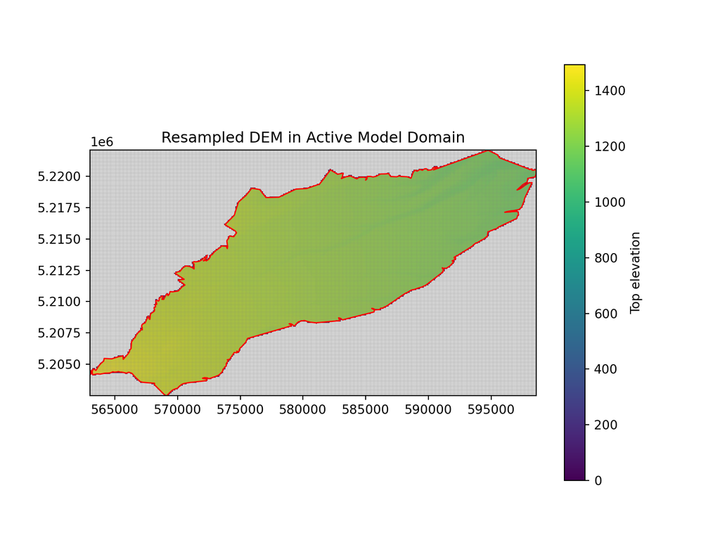

```python
ax.set_title("Resampled DEM in Active Model Domain")
ax.set_aspect("equal")
plt.show()
```

```python
## model layers, thickness
nlay = 1
thickness = 10.0  # meters, placeholder first-pass thickness

# Fill inactive cells so DIS gets a complete numeric array
fill_top = np.nanmin(top)
top_dis = np.where(np.isnan(top_active), fill_top, top_active)

botm = np.zeros((nlay, nrow, ncol), dtype=float)
botm[0] = top_dis - thickness

if np.any(botm[0] >= top_dis):
    raise ValueError("Bottom elevation is not below top everywhere.")

# bottom elevation check
fig, ax = plt.subplots(figsize=(8, 6))
pmv = flopy.plot.PlotMapView(modelgrid=modelgrid, ax=ax)
quad = pmv.plot_array(np.where(idomain[0] == 1, botm[0], np.nan))
pmv.plot_grid(alpha=0.15)
boundary.boundary.plot(ax=ax, color="red", linewidth=1)
plt.colorbar(quad, ax=ax, label="Bottom elevation")
```

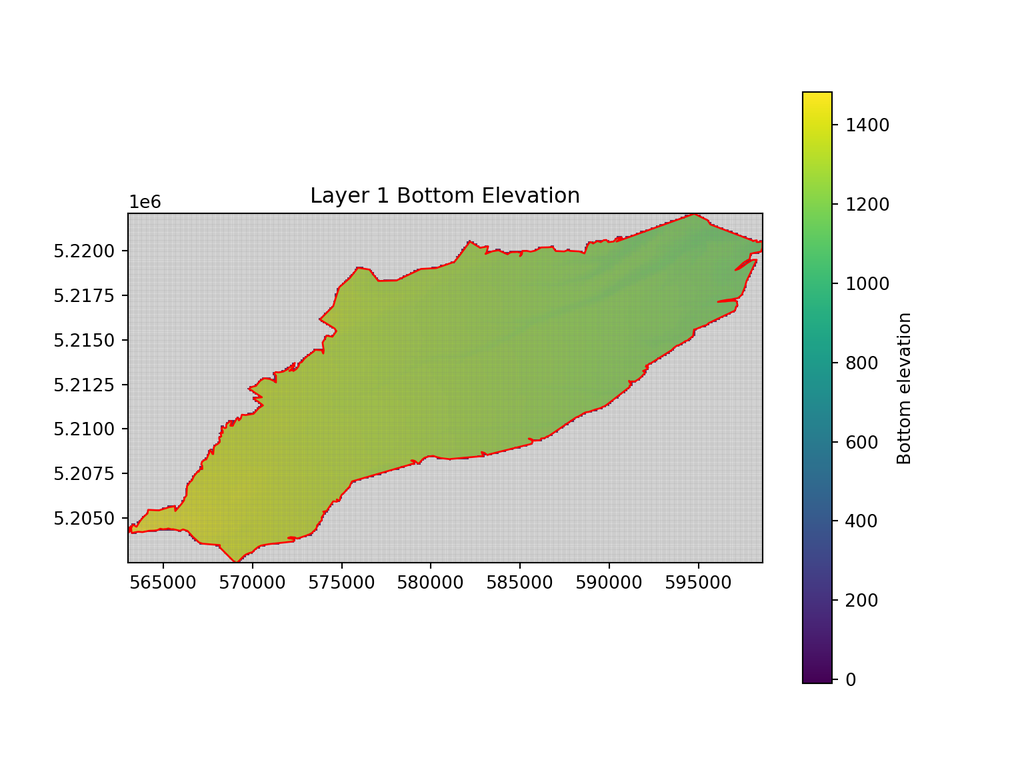

```python
ax.set_title("Layer 1 Bottom Elevation")
ax.set_aspect("equal")
plt.show()
```

# 7 NHD flowlines addition

```python
## adding in USGS NHD flowlines
flowlines = gpd.read_file(nhd_path)
print("Flowlines CRS:", flowlines.crs) ## checks starting crs
```

```python
## reproject if needed
if flowlines.crs != dem_crs: ## if crs is different than dem crs convert it
    flowlines = flowlines.to_crs(dem_crs)
print("Flowlines CRS:", flowlines.crs) ## check to make sure crs converted
```

```python
#$ clip to Moccasin boundary
flowlines_clip = gpd.clip(flowlines, boundary)

print(f"Original flowlines: {len(flowlines)}")
```

```python
print(f"Clipped flowlines: {len(flowlines_clip)}")
```

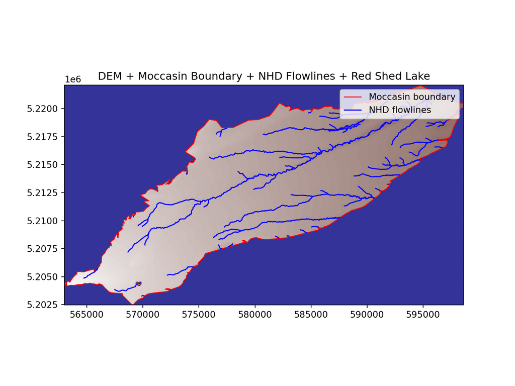

```python
## DEM, boundary, clipped flowlines check
fig, ax = plt.subplots(figsize=(8, 6))

ax.imshow(
    Moccasin_dem,
    cmap="terrain",
    extent=[left, right, bottom, top_raster]
)

boundary.boundary.plot(ax=ax, color="red", linewidth=1, label="Moccasin boundary")
flowlines_clip.plot(ax=ax, color="blue", linewidth=1.2, label="NHD flowlines")

red_shed_lake.plot(
    ax=ax,
    color="red",
    edgecolor="black",
    alpha=0.5,
    label="Red Shed Lake"
)

ax.set_title("DEM + Moccasin Boundary + NHD Flowlines + Red Shed Lake")
ax.set_aspect("equal")
ax.legend()

plt.show()
```

```python
## add in well location

df = pd.read_excel(M1_well_path) ## reading in well location data
print(df.head())
```

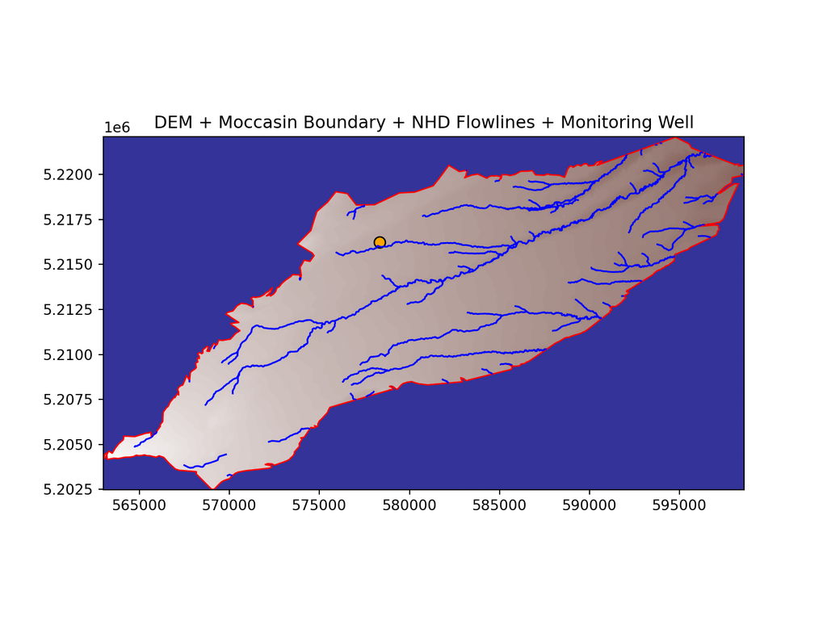

```python
well_gdf = gpd.GeoDataFrame(
    df,
    geometry=[Point(xy) for xy in zip(df["longDDS"], df["latDDS"])],
    crs="EPSG:4326"
)

well_gdf = well_gdf.to_crs(dem_crs) ## converting crs

well_gdf.plot(
    ax=ax,
    color="orange",
    edgecolor="black",
    markersize=60,
    marker="o"
)

## plot of DEM, boundary, USGS flowlines and monitoring well
fig, ax = plt.subplots(figsize=(8, 6))

ax.imshow(
    Moccasin_dem,
    cmap="terrain",
    extent=[left, right, bottom, top_raster]
)

boundary.boundary.plot(ax=ax, color="red", linewidth=1, label="Moccasin boundary")
flowlines_clip.plot(ax=ax, color="blue", linewidth=1.2, label="NHD flowlines")

well_gdf.plot(
    ax=ax,
    color="orange",
    edgecolor="black",
    markersize=60,
    marker="o",
    label="Monitoring well"
)

ax.set_title("DEM + Moccasin Boundary + NHD Flowlines + Monitoring Well")
ax.set_aspect("equal")

plt.show()
```

# 8 GWIC wells

```python
# GWIC wells: read, reproject, clip to Moccasin boundary
gwic_path = input_dir / "GWIC_Shapefile" / "GWIC_Wells.shp"

# read GWIC well points
gwic = gpd.read_file(gwic_path)

print("GWIC CRS:", gwic.crs)
```

```python
print("GWIC fields:", gwic.columns.tolist())
```

```python
# reproject to DEM/model CRS if needed
if gwic.crs != dem_crs:
    gwic = gwic.to_crs(dem_crs)
print("GWIC CRS:", gwic.crs)
```

```python
# clip wells to Moccasin boundary
gwic_clip = gpd.clip(gwic, boundary)

print("GWIC wells in Moccasin boundary:", len(gwic_clip))
```

```python
## copy of useful GWIC fields
gwic_well_list = gwic_clip[
    [
        "gwicid",
        "site_name",
        "latitude",
        "longitude",
        "geomethod",
        "altitude",
        "site_type",
        "township",
        "range",
        "section",
        "qsection",
        "county",
        "notes",
    ]
].copy()

gwic_well_list
```

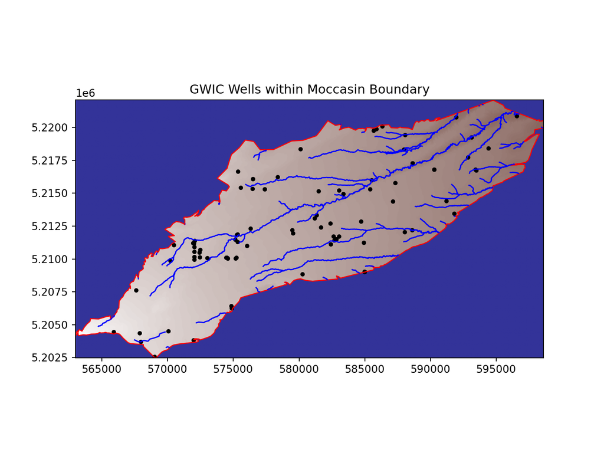

```python
# Plot GWIC wells inside Moccasin boundary
fig, ax = plt.subplots(figsize=(8, 6))

ax.imshow(
    Moccasin_dem,
    cmap="terrain",
    extent=[left, right, bottom, top_raster]
)

boundary.boundary.plot(ax=ax, color="red", linewidth=1)
flowlines_clip.plot(ax=ax, color="blue", linewidth=1.2)
gwic_clip.plot(ax=ax, color="black", markersize=10)

ax.set_title("GWIC Wells within Moccasin Boundary")
ax.set_aspect("equal")

plt.show()
```

```python
# Export well list for manual GWIC log review
gwic_out_csv = model_ws / "Moccasin_GWIC_wells_inside_boundary.csv"
gwic_well_list.to_csv(gwic_out_csv, index=False)

gwic_out_csv
```

The overall assessment for suitability in constructing an interpolated shale boundary based on well coverage is decidedly suspect. There is some clumping of wells deemed suitable for this purpose and many more wells that have no record or the confining boundary of the perched aquifer is more uncertain (maybe wells). The northeast section of the terrace has very little in terms of usable GWIC well logs. The most important point is that around the M1 monitoring well there is very little well log data with which to interpolate a confining layer. With static water level measurements, we could probably construct equipotential lines for head contours but right now the confining layer interpolation is mostly only useful as a conceptual for groundwater flow paths.

# 9 Bottom boundary interpolation

```python
## importing in modified csv with rough boundary depths in feet

gwic_csv = model_ws / "Moccasin_GWIC_wells_inside_boundary_bottom_depth_edit.csv"
gwic_labels = pd.read_csv(gwic_csv)

# create geometry from lat/long
gwic_gdf = gpd.GeoDataFrame(
    gwic_labels,
    geometry=gpd.points_from_xy(gwic_labels["longitude"], gwic_labels["latitude"]),
    crs="EPSG:4326"  # lat/long CRS
)
# project to DEM CRS
gwic_gdf = gwic_gdf.to_crs(dem_crs)

gwic_gdf.head()
```

```python
## check columns listed
gwic_labels.columns.tolist()
```

```python
## strip white space and
gwic_gdf["usable"] = gwic_gdf["usable"].str.strip().str.capitalize()
## check for trailing spaces
gwic_gdf["usable"].value_counts(dropna=False)
```

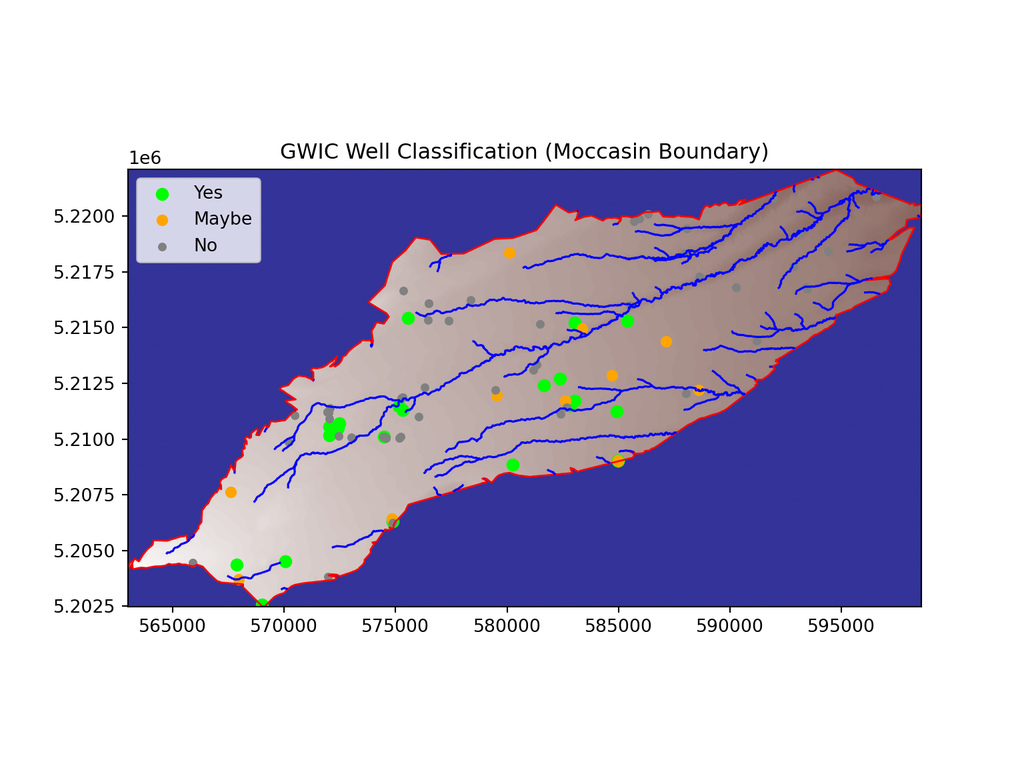

```python
## checking which wells make sense to work with, which are a maybe and which are not usable
fig, ax = plt.subplots(figsize=(8, 6))

# DEM
ax.imshow(
    Moccasin_dem,
    cmap="terrain",
    extent=[left, right, bottom, top_raster]
)

# boundary + streams
boundary.boundary.plot(ax=ax, color="red", linewidth=1)
flowlines_clip.plot(ax=ax, color="blue", linewidth=1.2)

gwic_gdf[gwic_gdf["usable"] == "Yes"].plot(
    ax=ax, color="lime", markersize=40, label="Yes"
)

gwic_gdf[gwic_gdf["usable"] == "Maybe"].plot(
    ax=ax, color="orange", markersize=30, label="Maybe"
)

gwic_gdf[gwic_gdf["usable"] == "No"].plot(
    ax=ax, color="gray", markersize=15, label="No"
)

ax.legend()
ax.set_title("GWIC Well Classification (Moccasin Boundary)")
ax.set_aspect("equal")

plt.show()
```

Seeing some low values around 2-5 meter depths to assumed confining material but a general pattern is emerging for ~7-12 meters. Worth a recheck on the 2-5. I did reassign the MSU CARC well 1929 a depth of 28ft. This is uncertain but overburden gravel and boulders is 0-28 ft. Overall, the depth to the assumed confining material based on GWIC well log lithologic descriptions is promising as a first pass.

```python
## labeling depths to assumed confining layer here

# convert confining boundary depth from ft to m
gwic_gdf["Confining_layer_boundary_ft"] = pd.to_numeric(
    gwic_gdf["Confining_layer_boundary_ft"],
    errors="coerce"
)

gwic_gdf["Confining_layer_boundary_m"] = (
    gwic_gdf["Confining_layer_boundary_ft"] * 0.3048
)

# plot with depth labels
fig, ax = plt.subplots(figsize=(8, 6))

ax.imshow(
    Moccasin_dem,
    cmap="terrain",
    extent=[left, right, bottom, top_raster]
)

boundary.boundary.plot(ax=ax, color="red", linewidth=1)
flowlines_clip.plot(ax=ax, color="blue", linewidth=1.2)

gwic_gdf[gwic_gdf["usable"] == "Yes"].plot(
    ax=ax, color="lime", markersize=40, label="Yes"
)

gwic_gdf[gwic_gdf["usable"] == "Maybe"].plot(
    ax=ax, color="orange", markersize=30, label="Maybe"
)

gwic_gdf[gwic_gdf["usable"] == "No"].plot(
    ax=ax, color="gray", markersize=15, label="No"
)

# label yes and maybe wells with depth in meters
label_gdf = gwic_gdf[
    gwic_gdf["usable"].isin(["Yes", "Maybe"]) &
    gwic_gdf["Confining_layer_boundary_m"].notna()
].copy()

for _, row in label_gdf.iterrows():
    x = row.geometry.x
    y = row.geometry.y
    depth_m = row["Confining_layer_boundary_m"]

    ax.text(
        x,
        y,
        f"{depth_m:.1f} m",
        fontsize=7,
        color="black",
        ha="left",
        va="bottom"
    )
```

```python
ax.legend()
```

```python
ax.set_title("GWIC Well Classification with Interpreted Boundary Depths")
```

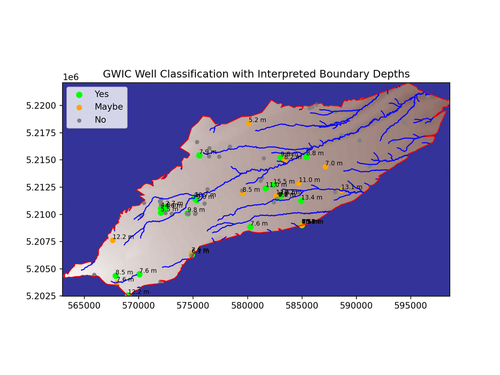

```python
ax.set_aspect("equal")

## save output for zooming
fig_out = model_ws / "GWIC_well_depths_map.png"
plt.savefig(fig_out, dpi=300, bbox_inches="tight")

plt.show()
```

```python
from scipy.interpolate import Rbf

## only use yes and maybe wells
interp_wells = gwic_gdf[
    gwic_gdf["usable"].isin(["Yes", "Maybe"]) &
    gwic_gdf["Confining_layer_boundary_m"].notna()
].copy()

## find well locations and depths
x = interp_wells.geometry.x.values
y = interp_wells.geometry.y.values
z = interp_wells["Confining_layer_boundary_m"].values

## predict depth at cell centers
xcenters = modelgrid.xcellcenters
ycenters = modelgrid.ycellcenters

# RBF interpolation strategy (smoother)
rbf = Rbf(
    x, y, z,
    function="linear",   # stable first choice
    smooth=2.0           # increase for smoother surface
)

## interpolate onto cell centers across grid
confining_depth_m = rbf(xcenters, ycenters)

# keep interpolated depths within observed range
zmin = np.nanmin(z)
zmax = np.nanmax(z)

confining_depth_m = np.clip(
    confining_depth_m,
    zmin,
    zmax
)

# mask outside active domain
confining_depth_active = np.where(
    idomain[0] == 1,
    confining_depth_m,
    np.nan
)

# Plot smoothed surface
fig, ax = plt.subplots(figsize=(8, 6))

pmv = flopy.plot.PlotMapView(modelgrid=modelgrid, ax=ax)
quad = pmv.plot_array(confining_depth_active)
pmv.plot_grid(alpha=0.05)
```

```python
boundary.boundary.plot(ax=ax, color="red", linewidth=1)
```

```python
flowlines_clip.plot(ax=ax, color="blue", linewidth=1.2)
```

```python
interp_wells.plot(
    ax=ax,
    column="usable",
    categorical=True,
    markersize=40,
    legend=True,
    legend_kwds={"loc": "lower right"}
)
```

```python
plt.colorbar(quad, ax=ax, label="Interpreted confining depth (m)")
```

```python
ax.set_title("Smoothed Interpolated Confining Layer Depth: Yes + Maybe Wells")
```

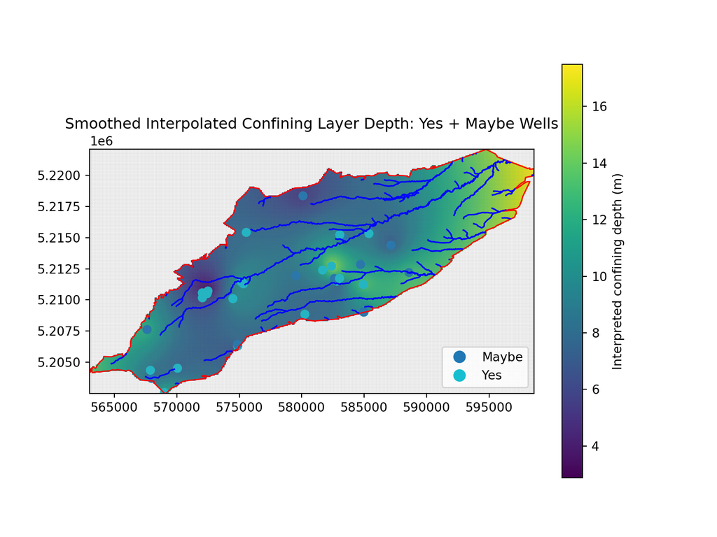

```python
ax.set_aspect("equal")

fig_out = model_ws / "smoothed_confining_depth_yes_maybe.png"
fig.savefig(fig_out, dpi=300, bbox_inches="tight")

plt.show()
```

```python
fig_out
```

```python
botm_interp = top_dis - confining_depth_m
```

```python
# Build interpolated bottom surface from Yes + Maybe
botm_interp = np.zeros((nlay, nrow, ncol), dtype=float)

# bottom = top - depth
botm_interp[0] = top_dis - confining_depth_m

# mask for plotting
botm_interp_active = np.where(idomain[0] == 1, botm_interp[0], np.nan)

# checking for values greater than top
bad_cells = botm_interp[0] >= top_dis
print("Cells where bottom >= top:", bad_cells.sum())
```

```python
# Plot interpolated bottom elevation
fig, ax = plt.subplots(figsize=(8, 6))

pmv = flopy.plot.PlotMapView(modelgrid=modelgrid, ax=ax)
quad = pmv.plot_array(botm_interp_active)
pmv.plot_grid(alpha=0.05)
```

```python
boundary.boundary.plot(ax=ax, color="red", linewidth=1)
```

```python
flowlines_clip.plot(ax=ax, color="blue", linewidth=1.2)
```

```python
plt.colorbar(quad, ax=ax, label="Bottom elevation (m)")
```

```python
ax.set_title("Interpolated Model Bottom: Yes + Maybe Wells")
```

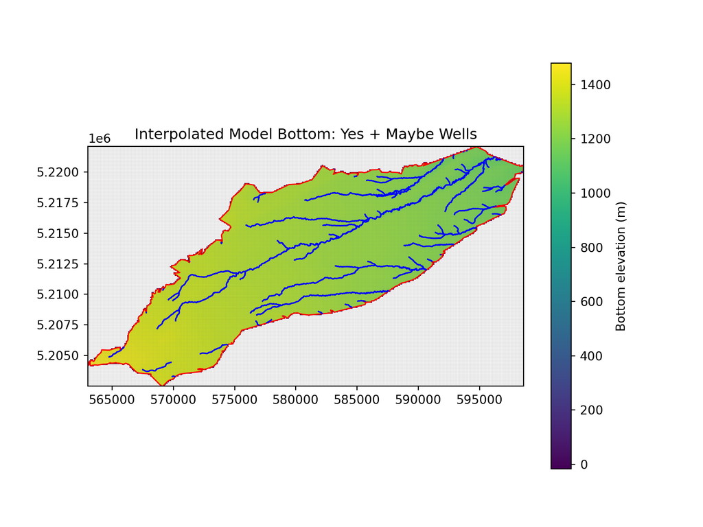

```python
ax.set_aspect("equal")

fig_out = model_ws / "interpolated_model_bottom_yes_maybe.png"
fig.savefig(fig_out, dpi=300, bbox_inches="tight")

plt.show()
```

```python
fig_out
```

```python
# Smooth interpolation using YES wells only
interp_wells_yes = gwic_gdf[
    (gwic_gdf["usable"] == "Yes") &
    gwic_gdf["Confining_layer_boundary_m"].notna()
].copy()

print("Yes interpolation wells:", len(interp_wells_yes))
```

```python
x = interp_wells_yes.geometry.x.values
y = interp_wells_yes.geometry.y.values
z = interp_wells_yes["Confining_layer_boundary_m"].values

xcenters = modelgrid.xcellcenters
ycenters = modelgrid.ycellcenters

rbf_yes = Rbf(
    x, y, z,
    function="linear",
    smooth=2.0
)

confining_depth_m_yes = rbf_yes(xcenters, ycenters)

zmin = np.nanmin(z)
zmax = np.nanmax(z)

confining_depth_m_yes = np.clip(
    confining_depth_m_yes,
    zmin,
    zmax
)

confining_depth_active_yes = np.where(
    idomain[0] == 1,
    confining_depth_m_yes,
    np.nan
)


# Plot YES-only interpolated surface
fig, ax = plt.subplots(figsize=(8, 6))

pmv = flopy.plot.PlotMapView(modelgrid=modelgrid, ax=ax)
quad = pmv.plot_array(confining_depth_active_yes)
pmv.plot_grid(alpha=0.05)
```

```python
boundary.boundary.plot(ax=ax, color="red", linewidth=1)
```

```python
flowlines_clip.plot(ax=ax, color="blue", linewidth=1.2)
```

```python
interp_wells_yes.plot(
    ax=ax,
    color="lime",
    edgecolor="black",
    markersize=45,
    label="Yes"
)
```

```python
plt.colorbar(quad, ax=ax, label="Interpreted confining depth (m)")
```

```python
ax.legend(loc="lower right")
```

```python
ax.set_title("Smoothed Interpolated Confining Layer Depth: Yes Wells Only")
```

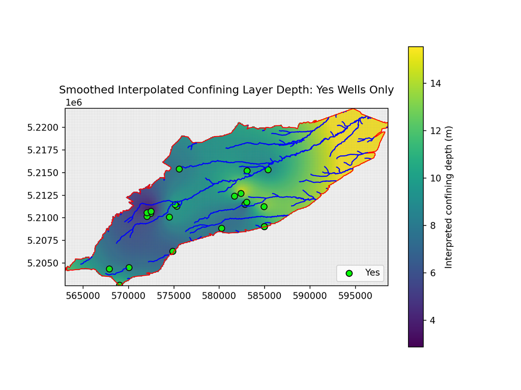

```python
ax.set_aspect("equal")

fig_out = model_ws / "smoothed_confining_depth_yes_only.png"
fig.savefig(fig_out, dpi=300, bbox_inches="tight")

plt.show()
```

```python
fig_out
```

# 10 Aquifer discharge calculations

```python
# Calculate terrace boundary area

print("Boundary CRS:", boundary.crs)
```

```python
# Reproject to an appropriate projected CRS if necessary
if boundary.crs.is_geographic:
    # Use UTM zone appropriate for the study area
    boundary_area = boundary.to_crs(boundary.estimate_utm_crs())
else:
    boundary_area = boundary

area_m2 = boundary_area.geometry.area.sum()

print(f"Terrace boundary area: {area_m2:,.2f} m²")
```

```python
print(f"Terrace boundary area: {area_m2 / 1_000_000:,.4f} km²")
```

```python
print(f"Terrace boundary area: {area_m2 / 4046.8564224:,.2f} acres")
```

```python
## making some assumptions about the aquifer here from previous work
## mainly Sigler et al. 2018

## assuming effective porosity of 0.35 and using Sigler's 3.6m saturated thickness
## estimate to give us a 1.26 m water height in the terrace aquifer

# 3. Estimate saturated aquifer volume

effective_porosity = 0.35
aquifer_material_depth_m = 3.6 # m
saturated_height_m =   effective_porosity * aquifer_material_depth_m # m

# Plan-view aquifer volume
saturated_aquifer_volume_m3 = area_m2 * saturated_height_m

# Water volume estimate
water_volume_m3 = area_m2 * saturated_height_m

print(f"Equivalent water height: {saturated_height_m:.2f} m")
```

```python
print(f"Water volume: {water_volume_m3:,.2f} m³")
```

```python
# 4. Estimate turnover flow

turnover_years = 20

annual_turnover_m3 = water_volume_m3 / turnover_years
daily_turnover_m3 = annual_turnover_m3 / 365.25

print(f"20-year annual turnover: {annual_turnover_m3:,.2f} m³/year")
```

```python
print(f"20-year daily turnover: {daily_turnover_m3:,.2f} m³/day")
```

# 11 Model simulation construction

```python
## Build final MF6 simulation

# Simulation

sim = flopy.mf6.MFSimulation(
    sim_name="moccasin",
    version="mf6",
    exe_name=r"D:\MODFLOW6\mf6.7.0_win64\bin\mf6.exe",
    sim_ws=str(model_ws),
)

# Stress periods

tdis = flopy.mf6.ModflowTdis(
    sim,
    time_units="DAYS",
    nper=1,
    perioddata=[(1.0, 1, 1.0)],
)

# Solver

ims = flopy.mf6.ModflowIms(
    sim,
    print_option="SUMMARY",
    complexity="SIMPLE",
)

# Groundwater flow model

gwf = flopy.mf6.ModflowGwf(
    sim,
    modelname="moccasin",
    save_flows=True,
)

# Structured grid

dis = flopy.mf6.ModflowGwfdis(
    gwf,
    nlay=nlay,
    nrow=nrow,
    ncol=ncol,
    delr=delr,
    delc=delc,
    top=top_dis,
    botm=botm_interp, # interpolated bottom
    idomain=idomain,
    xorigin=xmin,
    yorigin=ymin,
)


# Initial conditions

strt = np.minimum(
    botm_interp + saturated_height_m,
    top_dis - 0.01
)

ic = flopy.mf6.ModflowGwfic(
    gwf,
    strt=strt,
)

# Hydraulic properties

k_horiz = 10     # m/day
k_vert = 1       # m/day, common assumption for alluvial aquifers

npf = flopy.mf6.ModflowGwfnpf(
    gwf,
    icelltype=1,
    k=k_horiz,
    k33=k_vert,
    save_specific_discharge=True,
)


# Output control

oc = flopy.mf6.ModflowGwfoc(
    gwf,
    head_filerecord="moccasin.hds",
    budget_filerecord="moccasin.cbc",
    saverecord=[("HEAD", "ALL"), ("BUDGET", "ALL")],
    printrecord=[("HEAD", "LAST"), ("BUDGET", "LAST")],
)

## head of Red shed lake needed for chd package
## https://myfwp.mt.gov/fishMT/waterbody/42338
lake_head = 4544.2 * 0.3048 ## conversion from feet to meters,

print(f"Red Shed Lake CHD head: {lake_head:.3f} m")
```

```python
## quick sanity check
# Check Red Shed Lake CHD cells

print(f"Red Shed Lake CHD head: {lake_head:.3f} m")
```

```python
for cellid in lake_cells:
    _, r, c = cellid

    print(
        f"Cell ({r}, {c}) | "
        f"top = {top_dis[r,c]:.3f} m | "
        f"bottom = {botm_interp[0,r,c]:.3f} m | "
        f"CHD = {lake_head:.3f} m | "
        f"active = {idomain[0,r,c]}"
    )
```

```python
## based on the information I am seeing with the top elevations being
## lower than the given lake elevation value, I am updating the lake elevation
## https://www.anyplaceamerica.com/directory/mt/judith-basin-county-30045/lakes/red-shed-lake-775661/
## which lists the elevation as 4514 ft

lake_head = 4514 * 0.3048 ## conversion from feet to meters, updated elevation

for cellid in lake_cells:
    _, r, c = cellid

    print(
        f"Cell ({r}, {c}) | "
        f"top = {top_dis[r,c]:.3f} m | "
        f"bottom = {botm_interp[0,r,c]:.3f} m | "
        f"CHD = {lake_head:.3f} m | "
        f"active = {idomain[0,r,c]}"
    )
```

```python
## setting hydraulic head to lake_head elevation in previously defined lake cells
chd_spd = [
    (cellid, lake_head)
    for cellid in lake_cells
]

chd = flopy.mf6.ModflowGwfchd(
    gwf,
    stress_period_data=chd_spd,
    save_flows=True,
)
```

# 12 CHD simulation

```python
# CHD-only diagnostic run
# No recharge and no drainage for this diagnostic test.
# Red Shed Lake is the only hydraulic boundary condition.

ims = flopy.mf6.ModflowIms(
    sim,
    print_option="ALL",
    complexity="SIMPLE",
    outer_maximum=100,
    outer_dvclose=1e-4,
    inner_maximum=200,
    inner_dvclose=1e-5,
)

# Write and run model
sim.write_simulation()
```

```python
success, buff = sim.run_simulation(
    silent=False,
    report=True
)
```

```python
print("SUCCESS:", success)
```

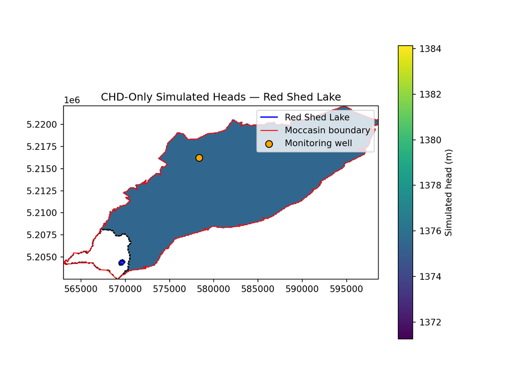

```python
# Plot CHD-only heads if model converged

if success:

    hds = flopy.utils.HeadFile(
        model_ws / "moccasin.hds"
    )

    head = hds.get_data(
        kstpkper=(0, 0)
    )

    head_active = np.where(
        idomain[0] == 1,
        head[0],
        np.nan
    )

    fig, ax = plt.subplots(figsize=(8, 6))

    pmv = flopy.plot.PlotMapView(
        model=gwf,
        ax=ax
    )

    quad = pmv.plot_array(head_active)

    levels = np.linspace(
        np.nanmin(head_active),
        np.nanmax(head_active),
        12
    )

    contours = ax.contour(
        modelgrid.xcellcenters,
        modelgrid.ycellcenters,
        head_active,
        levels=levels,
        colors="black",
        linewidths=0.7
    )

    ax.clabel(
        contours,
        inline=True,
        fontsize=8
    )

    # Red Shed Lake
    red_shed_lake.boundary.plot(
        ax=ax,
        color="blue",
        linewidth=1.5,
        label="Red Shed Lake"
    )

    # Moccasin Terrace boundary
    boundary.boundary.plot(
        ax=ax,
        color="red",
        linewidth=1,
        label="Moccasin boundary"
    )

    # M1 well
    well_gdf.plot(
        ax=ax,
        color="orange",
        edgecolor="black",
        markersize=60,
        label="Monitoring well"
    )

    plt.colorbar(
        quad,
        ax=ax,
        label="Simulated head (m)"
    )

    ax.set_title(
        "CHD-Only Simulated Heads — Red Shed Lake"
    )

    ax.set_aspect("equal")
    ax.legend()

    plt.show()
```

What we can see from this plot setup is that with only one CHD value and one very close to the surrounding DEM surface, we get only one simulated starting head across the terrace. An expected result. Now we could add a constant head at the M1 monitoring well but given we want to predict groundwater flow in this area, I am not inclined to do that. GWIC static water level data from well construction logs are from many different dates and years and are thus unsuitable.

For these reasons I am moving to a simple sensitivity test using reasonable recharge and discharge tests to see how that could impact hydraulic head gradients around the M1 monitoring well.

# 13 Recharge and discharge (in development)

This next code sections are still under development.

```python
# Add recharge + drainage to working CHD model

# DRN package from NHD flowlines

ix = GridIntersect(modelgrid)

drn_result = ix.intersect(
    flowlines_clip.geometry.union_all()
)

drn_spd = []

drn_cond = 2.5  # m2/day per DRN cell, first test value

for cellid in drn_result.cellids:

    r, c = cellid

    # First-pass stream/drain elevation
    drain_elev = top_dis[r, c] - 1.0

    if idomain[0, r, c] == 1:

        drn_spd.append(
            ((0, r, c), drain_elev, drn_cond)
        )

print(f"DRN cells: {len(drn_spd)}")
```

```python
print(f"DRN conductance per cell: {drn_cond:.2f} m²/day")
```

```python
print(
    f"Total nominal DRN conductance: "
    f"{len(drn_spd) * drn_cond:,.2f} m²/day"
)
```

```python
drn = flopy.mf6.ModflowGwfdrn(
    gwf,
    stress_period_data=drn_spd,
    save_flows=True,
)

# Recharge package

annual_precip_m = 0.40
recharge_fraction = 0.10

annual_recharge_m = (
    annual_precip_m * recharge_fraction
)

rch_rate = (
    annual_recharge_m / 365.25 ## per day value
)

print(f"Annual precipitation: {annual_precip_m:.2f} m/year")
```

```python
print(f"Assumed recharge fraction: {recharge_fraction:.0%}")
```

```python
print(f"Annual recharge: {annual_recharge_m:.3f} m/year")
```

```python
print(f"MODFLOW recharge rate: {rch_rate:.3e} m/day")
```

```python
rch = flopy.mf6.ModflowGwfrcha(
    gwf,
    recharge=rch_rate,
)

# Run CHD + RCH + DRN model

sim.write_simulation()
```

```python
success, buff = sim.run_simulation(
    silent=False,
    report=True
)
```

```python
print("SUCCESS:", success)
```

```python
## reading listing file for troubleshooting

lst_path = model_ws / "mfsim.lst"

if lst_path.exists():

    with open(lst_path, "r", errors="ignore") as f:
        lst_lines = f.readlines()

    print("=" * 80)
    print("LAST 150 LINES OF mfsim.lst")
    print("=" * 80)

    for line in lst_lines[-150:]:
        print(line.rstrip())
```